# Geographic Profiling in R

18 March 2018

## Linked Sexual Assaults in SE London

In Autumn 2017, the Met released a media appeal following a series of sexual assaults committed against females, mostly young girls in school uniform.

- All the offences took place on a weekday
- Offences were typically between 7am - 9am and between 3pm and 6pm
- Nearly all the offences took place on residential streets
- Offences spread across five London boroughs

Whilst the offences took place on foot, the offences were spread over a very large area, so the hypothesis was that perhaps the offender was taking public transport between the locations, although he could also be using a car.

## The Package

**Rgeoprofile** https://evolve.sbcs.qmul.ac.uk/lecomber/sample-page/geographic-profiling/geographic-profiling-in-r/

Mark Stevenson, Robert Verity, Richard Nichols and Steve Le Comber

The package comprises a list of functions that must be run in order.

The output is a geoprofile overlaid on Google Maps, and a list of hitscores that can be calculated for known locations, such as train stations or home addresses of violent or sexual offenders.

## Data

Your data will be comprised of two sets of coordinates:

- First Set - the coordinates of where the crimes too place
- Second Set - source data (optional) - the coordinates of places that may be an offender's anchor point (home address, work address, commuter stations)

The first function in the package is LoadData.

```r
LoadData(Data=crimes, sources=stations)
```

## Parameters for the Model

```r
assign("sigma", 0.01, .GlobalEnv)

ModelParameters(sigma = 0.01, tau = "DEFAULT", minburnin = 100,
                maxburnin = 1000, chains = 5, Samples = 10000)
```

The most important parameter is sigma. This will need to be altered to reflect the environment and the suspected mode of transport that the offender is using.

## Parameters for the Map

```r
GraphicParameters(Guardrail = 0.05, nring = 20, transp = 0.4,
                  gridsize = 640, gridsize2 = 600,
                  MapType = "roadmap", Location = getwd(),
                  pointcol = "black")
```

These values are all dependent on how you wish your final map to look. These parameters affect format, resolution and transparancy.

## Create Map

[figure not shown]

```r
CreateMaps(PlotPrior = T)
```

This is the map also with the stations plotted.

[figure not shown]

```r
points(stations, pch = 15 , col = "blue")
```

The next step runs the MCMC burn-in, sampling and produces diagnostic plos of convergence and autocorrelation.

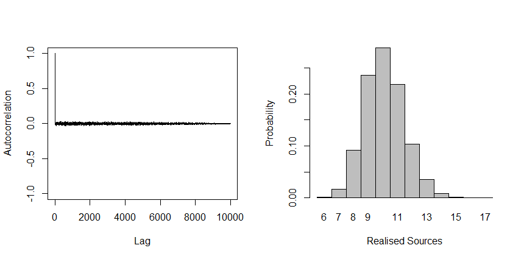

```r
RunMCMC()
```

```r
ThinandAnalyse(thinning = 100)
```

This step thins the samples produced by the MCMC step, and uses them for analysis and for building the geoprofile.

For example, a value of 100 would keep one sample out of every 100 samples.

```r
PlotGP(Window = "DEFAULT" , Legend = T)
```

This last step creates your geoprofile for you to view

The final output should look like a reverse heat map. The areas of white/pale yellow represent an area of interest.

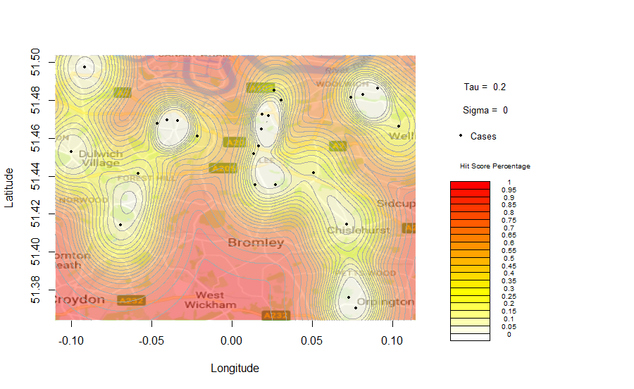

## HitScores

```r
Reporthitscores()
```

The hit scores will be assigned to each location in your source data. The closer to 0 this number is, the greater probability the offender's anchor point is located there. This may aid operational search activity, and help prioritise a long list of offenders.

Whilst it was still unknown how the offender was travelling between the various locations, the rail stations of Brockley, Crofton Park and Kidbrooke had a hit score of < 0.05 so these were raised as stations where there may be CCTV available.

An offender has been arrested and charged with a number of the offences in the series. His home address is located in an area of the geoprofile with a hit score of < 0.05

## Useful Links

Geographic Profiling Overview https://evolve.sbcs.qmul.ac.uk/lecomber/sample-page/geographic-profiling/

Rgeoprofile Package Overview https://evolve.sbcs.qmul.ac.uk/lecomber/sample-page/geographic-profiling/geographic-profiling-in-r/

## Contact Details

Danielle Kelly danielle.kelly@btp.pnn.police.uk

Sexual Offences Coordination Unit - British Transport Police